# R for Data Science

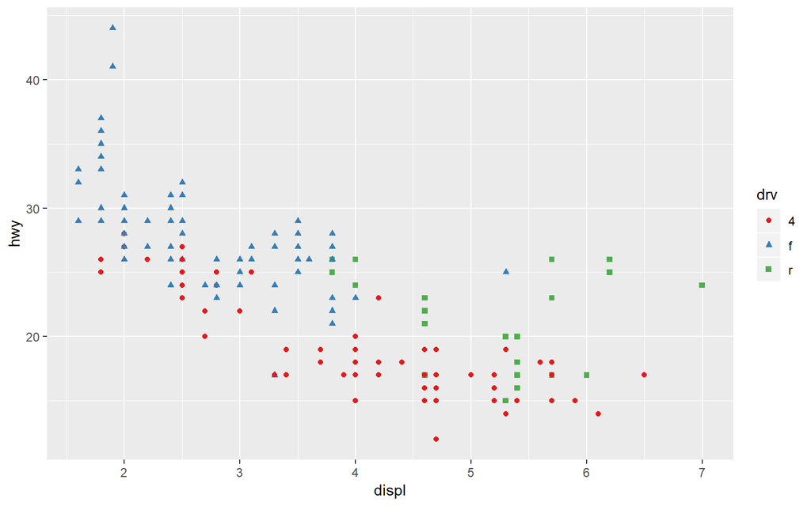

```r
# 해석이 더 쉽다.
ggplot(mpg, aes(displ, hwy)) +
  geom_point(aes(color = drv, shape = drv)) +
  scale_color_brewer(palette = "Set1")
```

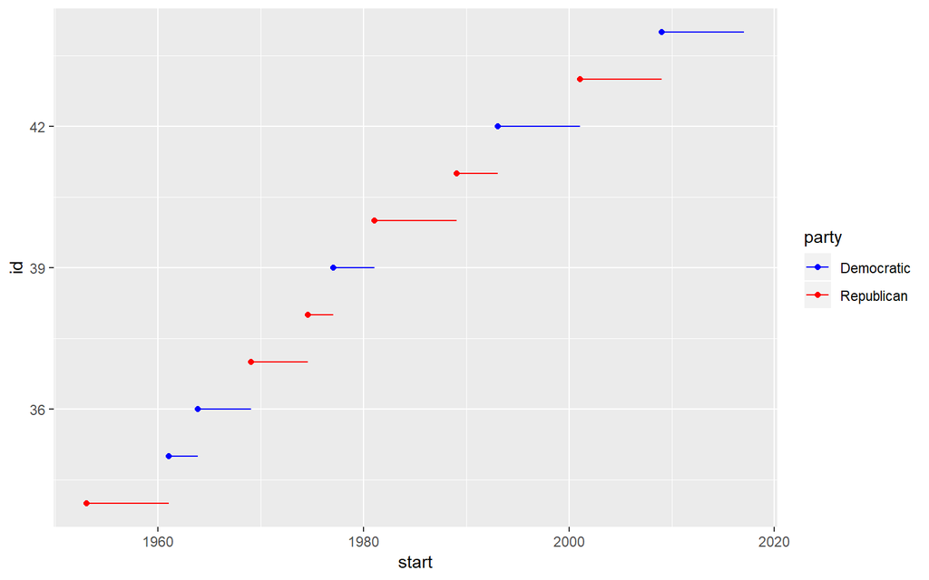

```r
presidential %>%
  mutate(id = 33 + row_number()) %>%
  ggplot(aes(start, id, color = party)) +
    geom_point() +
    geom_segment(aes(xend = end, yend = id)) +
    scale_color_manual(
      values = c(Republican = "red", Democratic = "blue")
    )
```

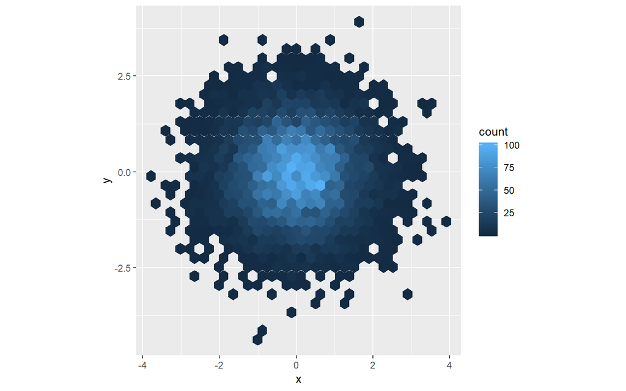

```r
df <- tibble(
  x = rnorm(10000),
  y = rnorm(10000)
)
ggplot(df, aes(x, y)) +
  geom_hex() +
  coord_fixed()
```

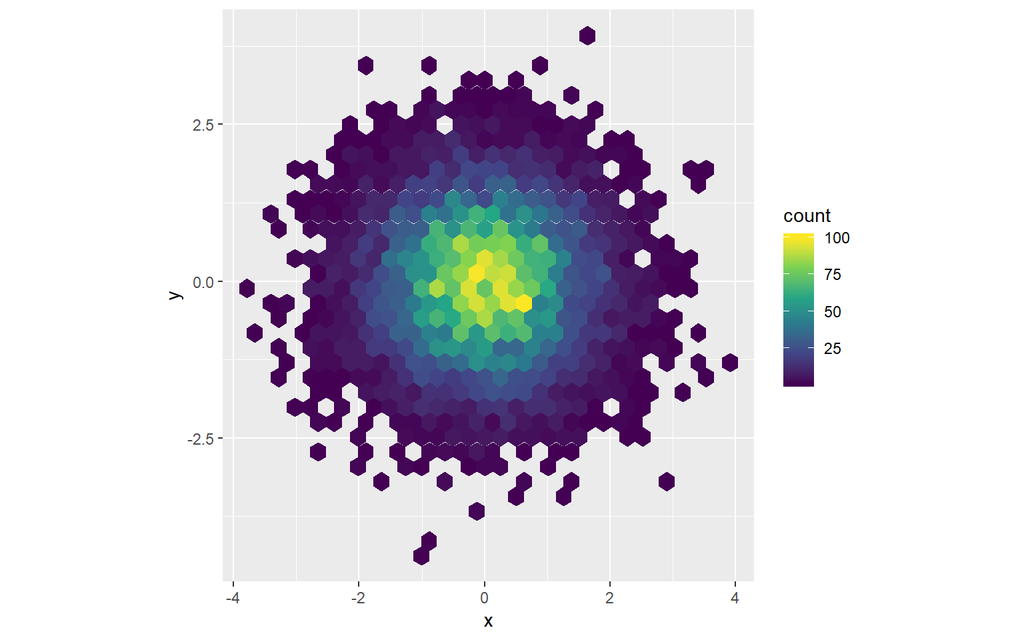

```r
ggplot(df, aes(x, y)) +
  geom_hex() +
  scale_fill_viridis_c() +
  coord_fixed()
```

## 2.6 Exercises

1. Why doesn’t the following code override the default scale?

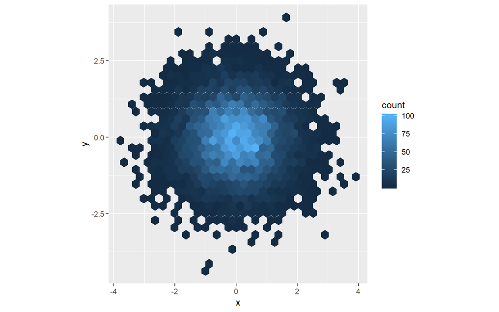

```r
ggplot(df, aes(x, y)) +
  geom_hex() +
  scale_color_gradient(low = "white", high = "red") +
  coord_fixed()
```

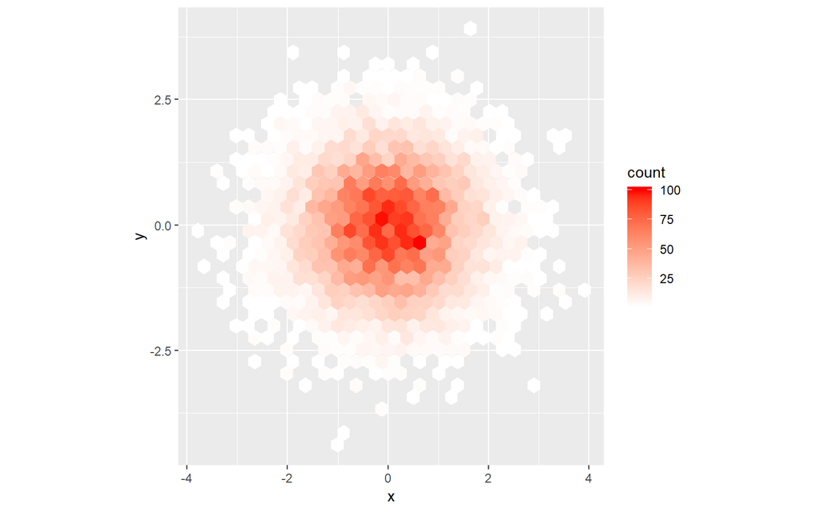

```r
ggplot(df, aes(x, y)) +
  geom_hex() +
  scale_fill_gradient(low = "white", high = "red") +
  coord_fixed()
```

2. Change the display of the presidential terms by:
1. Combining the two variants shown above.
2. Improving the display of the y-axis.
3. Labeling each term with the name of the president.
4. Adding informative plot labels.
5. Placing breaks every four years (this is trickier than it seems!).

date_breaks: “2 weeks”같은 문자열 사용 가능 breaks: 함수사용가능

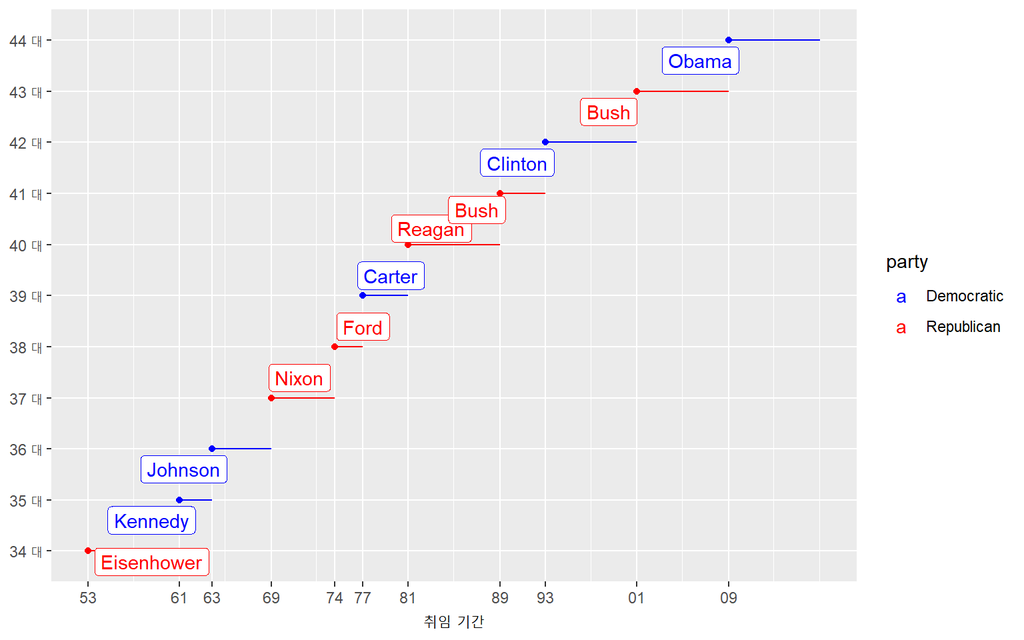

```r
presidential %>%
  mutate(id = 33 + row_number(),
         name_id = str_c(id, " 대"),
         name_id = factor(name_id, levels = unique(name_id))) %>%
  ggplot(aes(start, name_id, color = party)) +
    geom_point() +
    geom_segment(aes(xend = end, yend = name_id)) +
    scale_color_manual(
      values = c(Republican = "red", Democratic = "blue")
    ) +
    scale_x_date(
      breaks = presidential$start,
      date_minor_breaks = "4 years",
      date_labels = "%y"
    ) +
    # name_id대신 id를 사용한다면
    # scale_y_continuous(
    #   breaks = 33 + seq_len(nrow(presidential))
    # ) +
    ggrepel::geom_label_repel(aes(label = name)) +
    labs(x = "취임 기간" , y = NULL) +
    theme(panel.grid.minor.y = element_blank())
```

4. Use override.aes to make the legend on the following plot easier to see:

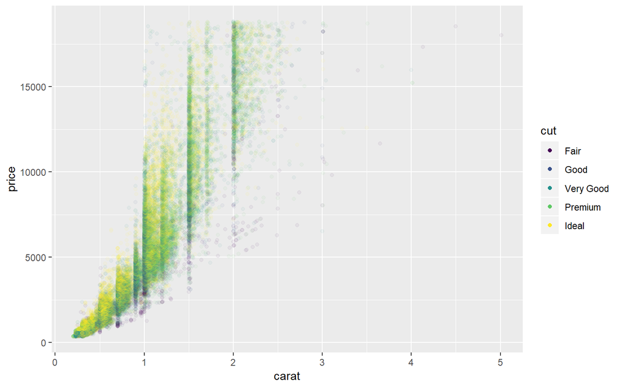

```r
ggplot(diamonds, aes(carat, price)) +
  geom_point(aes(color = cut), alpha = 1/20) +
  guides(
    color = guide_legend(override.aes = list(alpha = 1))
  )
```

외우려고 하지말고 ggplot2의 문법을 생각하면 list(alpha = 1)을 이해할 수 있다.

## 2.7 Zooming

- 데이터가 그려지는 것을 조정
- 각 스케일에 limit 설정
- coord_cartesian에서 xlim and ylim설정

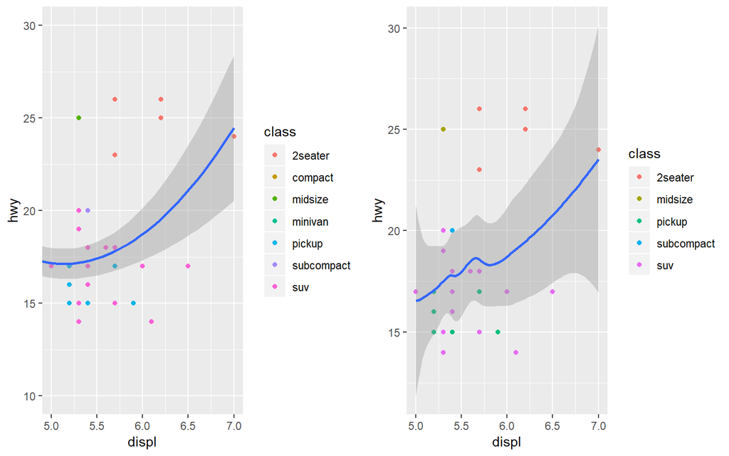

```r
grid.arrange(
ggplot(mpg, aes(displ, hwy)) +
  geom_point(aes(color = class)) +
  geom_smooth() +
  coord_cartesian(xlim = c(5, 7), ylim = c(10, 30)),

mpg %>%
  filter(between(displ, 5, 7), between(hwy, 10, 30)) %>%
  ggplot(aes(displ, hwy)) +
  geom_point(aes(color = class)) +
  geom_smooth(),

ncol = 2)
```

```r
suv <- mpg %>% filter(class == "suv")
compact <- mpg %>% filter(class == "compact")
```

```r
ggplot(suv, aes(displ, hwy, color = drv)) +
  geom_point()
ggplot(compact, aes(displ, hwy, color = drv)) +
  geom_point()
```

[output not shown]

두 플랏을 비교하기 어렵다. 이 문제를 해결하기 위해서는 다수의 플랏에서 스케일을 공유하도록 전체 데이터의 limits를 가지고 스케일을 훈련하는 것이다.

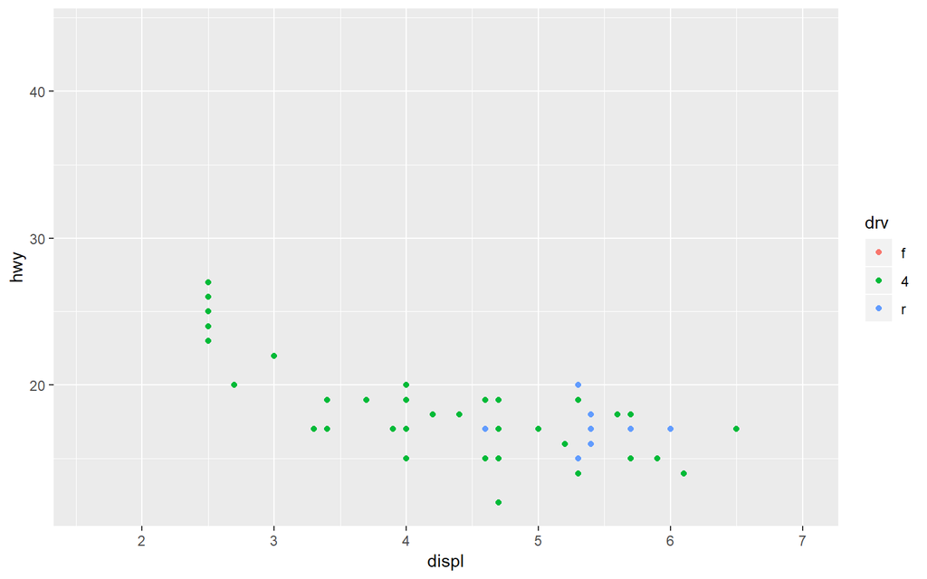

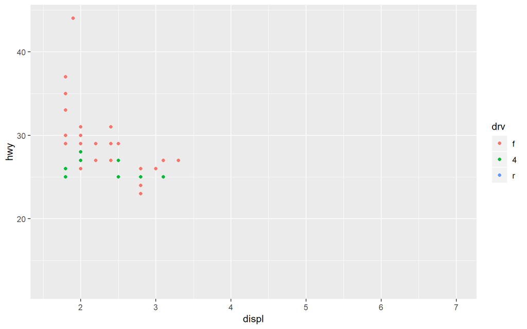

```r
x_scale <- scale_x_continuous(limits = range(mpg$displ))
y_scale <- scale_y_continuous(limits = range(mpg$hwy))
col_scale <- scale_color_discrete(limits = unique(mpg$drv))

ggplot(suv, aes(displ, hwy, color = drv)) +
  geom_point() +
  x_scale +
  y_scale +
  col_scale
ggplot(compact, aes(displ, hwy, color = drv)) +
  geom_point() +
  x_scale +
  y_scale +
  col_scale
```

facet를 사용해도 되지만 이것은 좀 더 일반적이다. 보고서의 여러 페이지에 플랏을 분산시킬 때 처럼.

## 2.8 Themes

바탕이 회색인 이유는 격자선을 더 잘 보이게 하기 위해, 인쇄상의 문제, single visual entity로써 지각되는 것을 보장하기 위해.

## 2.9 Saving Your Plots

`ggsave("my-plot.pdf")`

### 2.9.1 figure Sizing

두 개의 사이즈가 있는데 하나는 R에 의해 만들어지는 그림의 크기이고 하나는 문서에 삽입되는 크기이다.

- `fig.width = 6` and `fig.asp = 0.618`(황금비). 각 청크에서는 fig.asp만을 조정한다.
- `out.width = "70%"` and `fig.align = "center"`
- 하나의 행에 다수의 플랏을 넣고 싶다면, 두 개의 플랏은 `out.width = "50%"` 세 개의 플랏은 “33%”, 네 개는 “25%”. `fig.align = "default"`. 설명하기 위해 또한 `fi.width`를 조정한다.

플랏의 텍스트를 가늘게 뜨고 봐야 한다면 `fig.width`를 조정할 필요가 있다. `fig.width`가 최종 문서에서 랜더링 되는 그림의 사이즈 보다 크다면 텍스트는 아주 작아질 것이다. 만약 `fig.width`가 작다면 텍스트는 아주 커질 것이다.

### 2.9.2 Other Important Options

코드와 텍스트를 석을 때, 코드 위에 플랏을 보여주기 위해 `fig.show = "hold"`.